# Clustering for Segmentation

# Dataset

This dataset is derived from a survey of customers of financial services.

Respondents were asked to rate the importance of 12 factors in selecting a primary financial provider  
These include:  
- performance of investments,  
- fees or commissions charged,  
- depth of products,  
- ability to resolve problems,  
- online services offered,  
- multiple providers’ products to choose from,  
- quality of advice,  
- knowledge of representatives,  
- representative knowing needs,  
- access to other professional services,  
- degree to which providers knows customer, and  
- quality of service.

Each item was rated on a 1-5 scale where 1 is not at all important and 5 is extremely important.

Data also includes (i) age, (ii) marital status and (iii) education of respondents.

*Source: Malhotra, Naresh (2010), Marketing Research, 6th ed, Pearson, p. 808-813*

## Read Data

You must read the data before trying to run code on your own machine. To read data use the following code after setting your working directory. To set your working directory, modify the following to set the file path for the folder where the data file resides. setwd(‘C:/Users/Columbia/AAFM2’)

```r
data = read.csv(file = 'jpm_cluster.csv',stringsAsFactors = F)
```

```r
str(data)
```

```
## 'data.frame':    500 obs. of  16 variables:
##  $ id                    : int  1 2 3 4 5 6 7 8 9 10 ...
##  $ Q1_a                  : int  3 NA 5 5 5 5 5 4 5 4 ...
##  $ Q1_b                  : int  3 NA 5 3 5 3 4 4 3 4 ...
##  $ Q1_c                  : int  NA 4 3 5 4 5 5 3 5 3 ...
##  $ Q1_d                  : int  5 NA 2 5 4 4 5 4 5 3 ...
##  $ Q1_e                  : int  1 NA 3 4 4 NA 3 3 4 1 ...
##  $ Q1_f                  : int  3 NA 1 4 5 3 3 3 4 4 ...
##  $ Q1_g                  : int  5 NA 5 4 5 5 5 4 5 5 ...
##  $ Q1_h                  : int  5 4 5 5 5 5 5 4 5 5 ...
##  $ Q1_i                  : int  5 NA 2 5 5 4 5 4 5 4 ...
##  $ Q1_j                  : int  4 NA 2 4 4 5 5 3 3 2 ...
##  $ Q1_k                  : int  5 NA 4 5 5 5 5 4 5 4 ...
##  $ Q1_l                  : int  4 4 5 5 4 5 5 4 5 4 ...
##  $ Age_Recoded           : int  3 2 1 2 4 NA 1 2 2 2 ...
##  $ Marital_Status_Recoded: int  1 1 1 1 1 NA 1 1 1 1 ...
##  $ Education_Recoded     : int  2 1 5 3 2 NA 3 6 3 5 ...
```

## Select Variables

### Label Data

Naming columns based on survey. Also, assigning value labels to categories of demographic variables.

```r
names(data) = c('id','performance','fees_commissions','depth_of_products','ability_resolve_problems',
                'online_services','choice_of_providers','quality_of_advice','knowledge_of_reps',
                'rep_knowing_your_needs','professional_services','provider_knows_me',
                'quality_of_service','age','marital_status','education')
data$age = factor(data$age,labels = c('27-57','58-68','69-75','75+'))
data$marital_status = factor(data$marital_status,labels=c('married','not married'))
data$education = factor(data$education,labels=c('no college','some college','college graduate',
                                                'some graduate school','masters degree','doctorate'))
str(data)
```

```
## 'data.frame':    500 obs. of  16 variables:
##  $ id                      : int  1 2 3 4 5 6 7 8 9 10 ...
##  $ performance             : int  3 NA 5 5 5 5 5 4 5 4 ...
##  $ fees_commissions        : int  3 NA 5 3 5 3 4 4 3 4 ...
##  $ depth_of_products       : int  NA 4 3 5 4 5 5 3 5 3 ...
##  $ ability_resolve_problems: int  5 NA 2 5 4 4 5 4 5 3 ...
##  $ online_services         : int  1 NA 3 4 4 NA 3 3 4 1 ...
##  $ choice_of_providers     : int  3 NA 1 4 5 3 3 3 4 4 ...
##  $ quality_of_advice       : int  5 NA 5 4 5 5 5 4 5 5 ...
##  $ knowledge_of_reps       : int  5 4 5 5 5 5 5 4 5 5 ...
##  $ rep_knowing_your_needs  : int  5 NA 2 5 5 4 5 4 5 4 ...
##  $ professional_services   : int  4 NA 2 4 4 5 5 3 3 2 ...
##  $ provider_knows_me       : int  5 NA 4 5 5 5 5 4 5 4 ...
##  $ quality_of_service      : int  4 4 5 5 4 5 5 4 5 4 ...
##  $ age                     : Factor w/ 4 levels "27-57","58-68",..: 3 2 1 2 4 NA 1 2 2 2 ...
##  $ marital_status          : Factor w/ 2 levels "married","not married": 1 1 1 1 1 NA 1 1 1 1 ...
##  $ education               : Factor w/ 6 levels "no college","some college",..: 2 1 5 3 2 NA 3 6 3 5 ...
```

### Subset needs-based variables

Variables in columns 2 - 13 include the needs based-variables. These variables reflect respondent importance rating of twelve features of financial services. We will subset these twelve variables. Five of the 12 variables are displayed.

```r
data_cluster = data[,2:13]
head(data_cluster[,1:5])
```

|  | performance | fees_commissions | depth_of_products | ability_resolve_problems | online_services |
| --- | --- | --- | --- | --- | --- |
| 1 | 3 | 3 | NA | 5 | 1 |
| 2 | NA | NA | 4 | NA | NA |
| 3 | 5 | 5 | 3 | 2 | 3 |
| 4 | 5 | 3 | 5 | 5 | 4 |
| 5 | 5 | 5 | 4 | 4 | 4 |
| 6 | 5 | 3 | 5 | 4 | NA |

##### Examine the subset data

How many observations are in the subset.

```r
str(data_cluster)
```

```
## 'data.frame':    500 obs. of  12 variables:
##  $ performance             : int  3 NA 5 5 5 5 5 4 5 4 ...
##  $ fees_commissions        : int  3 NA 5 3 5 3 4 4 3 4 ...
##  $ depth_of_products       : int  NA 4 3 5 4 5 5 3 5 3 ...
##  $ ability_resolve_problems: int  5 NA 2 5 4 4 5 4 5 3 ...
##  $ online_services         : int  1 NA 3 4 4 NA 3 3 4 1 ...
##  $ choice_of_providers     : int  3 NA 1 4 5 3 3 3 4 4 ...
##  $ quality_of_advice       : int  5 NA 5 4 5 5 5 4 5 5 ...
##  $ knowledge_of_reps       : int  5 4 5 5 5 5 5 4 5 5 ...
##  $ rep_knowing_your_needs  : int  5 NA 2 5 5 4 5 4 5 4 ...
##  $ professional_services   : int  4 NA 2 4 4 5 5 3 3 2 ...
##  $ provider_knows_me       : int  5 NA 4 5 5 5 5 4 5 4 ...
##  $ quality_of_service      : int  4 4 5 5 4 5 5 4 5 4 ...
```

```r
nrow(data_cluster)
```

```
## [1] 500
```

How many missing values are there for the variable performance are in the subset

```r
sum(is.na(data_cluster$performance))
```

```
## [1] 42
```

How many rows of data would be left if rows corresponding to missing values on any of the variables were removed. Let’s use na.omit() and not to overwirte the original subset

```r
nrow(na.omit(data_cluster))
```

```
## [1] 396
```

## Prepare Data

### Transform format of variables

Clustering algorithms prefer all variables to be of the same class (e.g., numeric, factor). Furthermore, algorithms differ in the class of variables required (e.g., hclust and k-means work with numeric while polCA works with factor).

Since all the survey responses in this dataset are numeric variables, there is no need to change the class of the variables.

Note: It is common to treat survey responses gathered on 1-5 scale to be numeric, as we have done here. However, some researchers contend that responses to itemized rating scales are ordinal, which in R are represented by an ordered factor.

### Impute missing data

Clustering algorithms use data on all variables. A missing observation on one variable will cause the entire row of data to be ignored for analysis. Therefore, it is important to impute missing values.

Let us impute the missing values. There are many packages and functions in R to use for imputation. We are going to make use of the mice package with the default method, predictive mean matching. Setting the seed is critical for getting consistent results. In newer version of the `mice` library, it implemented a new match index C function that makes predictive mean matching 50 to 600 times faster, however this affects reproducibility of the algorithm. Read more about the latest version [here](https://cran.r-project.org/web/packages/mice/news/news.html). In order to reproduce the original behavior, include `use.matcher=T` in the `mice` function. This is critically important, especially when completing the associated assignment. Finally, `tidyr` has an identically named `complete` function. To prevent conflicts, it is best to include the package reference, `mice::complete(...)`

```r
library(mice)
set.seed(617)
data_cluster = mice::complete(mice(data_cluster,use.matcher=T))
```

Running the `mice` function in interactive mode will generate a lengthy output of the iterative process. If you would rather not see this output, you can gather the output of the iterative process in a garbage collector variable as illustrated below.

```r
garbage = capture.output(data_cluster <- mice::complete(mice(data_cluster,use.matcher=T)))
```

Now, let’s examine the imputed values for the first few rows of the first four variables.

```r
head(data_cluster[,1:4])
```

|  | performance | fees_commissions | depth_of_products | ability_resolve_problems |
| --- | --- | --- | --- | --- |
| 1 | 3 | 3 | 4 | 5 |
| 2 | 4 | 4 | 4 | 4 |
| 3 | 5 | 5 | 3 | 2 |
| 4 | 5 | 3 | 5 | 5 |
| 5 | 5 | 5 | 4 | 4 |
| 6 | 5 | 3 | 5 | 4 |

```r
data_cluster$performance[2]
```

```
## [1] 4
```

### Scale

For distance-based clustering methods, scale of the variable (e.g., seconds vs minutes) affects the weight assigned to the variable. Therefore, it is best to standardize variables.

There are many ways to standardize a variables. Here, we are using scale() which will by default subtract mean and divide by standard deviation. One thing to be cautious of is that scale() returns a matrix. Examine the standardized values of the first four variables and the second observation of the variable performance.

```r
data_cluster = scale(data_cluster)
head(data_cluster[,1:4])
```

```
##      performance fees_commissions depth_of_products ability_resolve_problems
## [1,]  -1.3928295       -0.8440928         0.2078544               1.09390272
## [2,]  -0.3147881        0.2549864         0.2078544               0.05209061
## [3,]   0.7632533        1.3540656        -0.8314177              -2.03153363
## [4,]   0.7632533       -0.8440928         1.2471266               1.09390272
## [5,]   0.7632533        1.3540656         0.2078544               0.05209061
## [6,]   0.7632533       -0.8440928         1.2471266               0.05209061
```

```r
data_cluster[2,1]
```

```
## performance
##  -0.3147881
```

### Redundant variables

Multiple variables measuring the same dimension should be replaced by the underlying factor or a representative variable. Imagine a survey that uses 3 questions to measure restaurant service and 1 question to measure food quality in the restaurant. Used as such cluster analysis will on average weight restaurant service three times as much as food quality. When faced with multiple variables measuring an underlying factor, it is best to run a factor analysis and use factors instead of variables. Alternatively, one could combine correlated variables into a single component based on the results of a principal components analysis.

Since we have not examined dimension reduction methods yet, let us assume the survey items used here do not tap any underlying factor and move along.

# Clustering Methods

Clustering algorithms can be broadly categorized into

- **Distance-based methods**: Find groups that minimize the distance between members within the group while maximizing the distance from members of other groups. Popular methods are Hierarchical clustering and k-means.
- **Model-based methods**: View the data as a mixture of groups sampled from different distributions

Let us begin with Hierarchical Cluster Analysis

# Hierarchical Cluster Analysis

- Popular method that groups observations according to their similarity
- Distance-based algorithm that operates on a dissimilarity matrix
- Algorithm begins with each observation in its own cluster
- Successively joins neighboring observations or clusters on at a time according to their distances from one another, and continues until all observations are linked
- Process of repeatedly joining observations is called the agglomerative method

## Compute Similarity Measure

Similarity is generally measured using a distance-based measure (as opposed to a correlational measure). Here, we will make use of Euclidean distance to assess similarity. Now, it is important to note that Euclidean distance only works with integer or numeric data. If data also includes a factor, an alternative is to use daisy() from library(cluster).

```r
d = dist(x = data_cluster,method = 'euclidean')
```

How many elements are in the distance matrix?

```r
length(d)
```

```
## [1] 124750
```

## Clustering Method

Distance between pairs of points is useful in identifying similarity between a pair of points. As observations are combined into clusters, distances must now be evaluated among clusters or between a point and a cluster. There are different approaches to grouping observations and these are called clustering methods. These methods differ based on whether they are based on distance (single, complete, linkage), variance (ward.D2, ward.D) or centroid (median, centroid).

Let us conduct hierarchical clustering using Ward’s method.

```r
clusters = hclust(d = d,method='ward.D2')
```

## Intepret Results

### Examine Dendrogram

The ultimate result of cluster analysis is a dendrogram which looks a bit like an inverted tree. A hierarchical dendrogram is interpreted primarily by height and where observations are joined. The height represents the dissimilarity between elements that are joined.

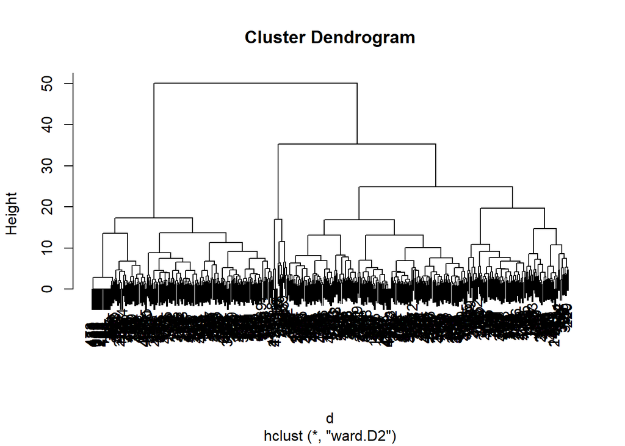

```r
plot(clusters)
```

### Goodness of Fit

Before moving on to deciphering the dendrogram, it is useful to look at the Cophenetic correlation coefficient. Cophenetic correlation coefficient (CPC) is a goodness of fit statistic for hierarchical clustering which assesses how well a dendrogram matches the true distance metric. It is interpreted similar to a correlation coefficient. CPC> 0.7 indicates relatively strong fit, 0.3<CPC<0.7 indicates moderate fit.

```r
cor(cophenetic(clusters),d)
```

```
## [1] 0.3479761
```

### Number of Clusters

Even a moderate sized data will make the leaves of the dendrogram look very busy. To clarify the picture we cut the dendrogram to only display the tree above a certain height.

Let’s only disply the tree above 5. Based on the distances, a two or three cluster solution looks good.

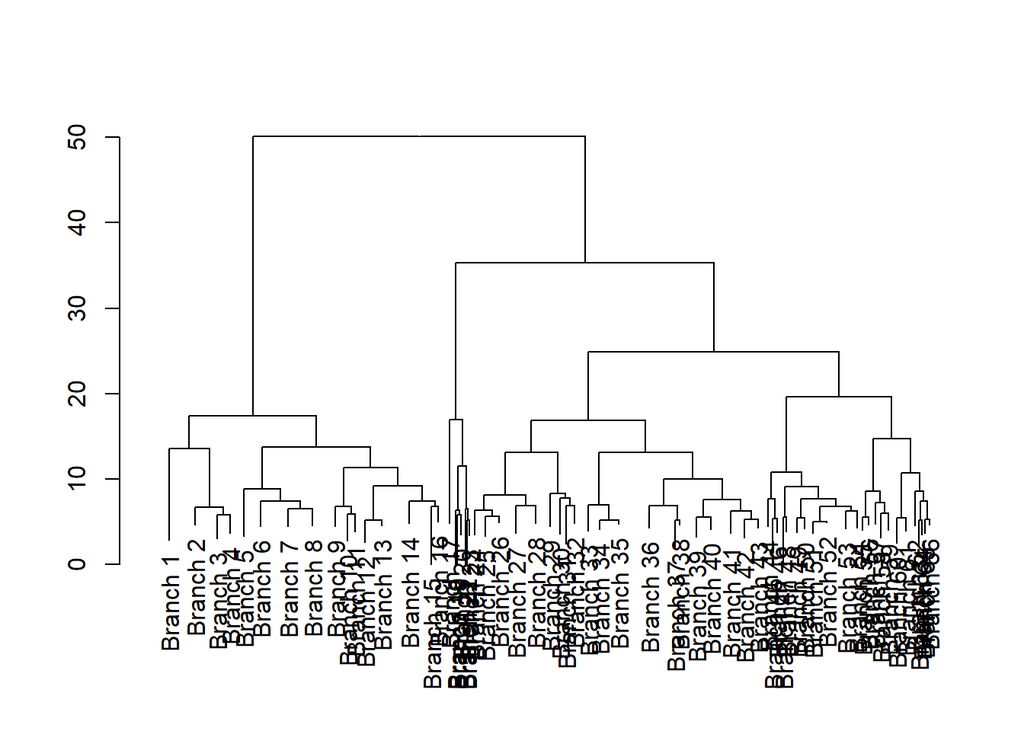

```r
plot(cut(as.dendrogram(clusters),h=5)$upper)
```

Let us draw rectangles around a two cluster solution

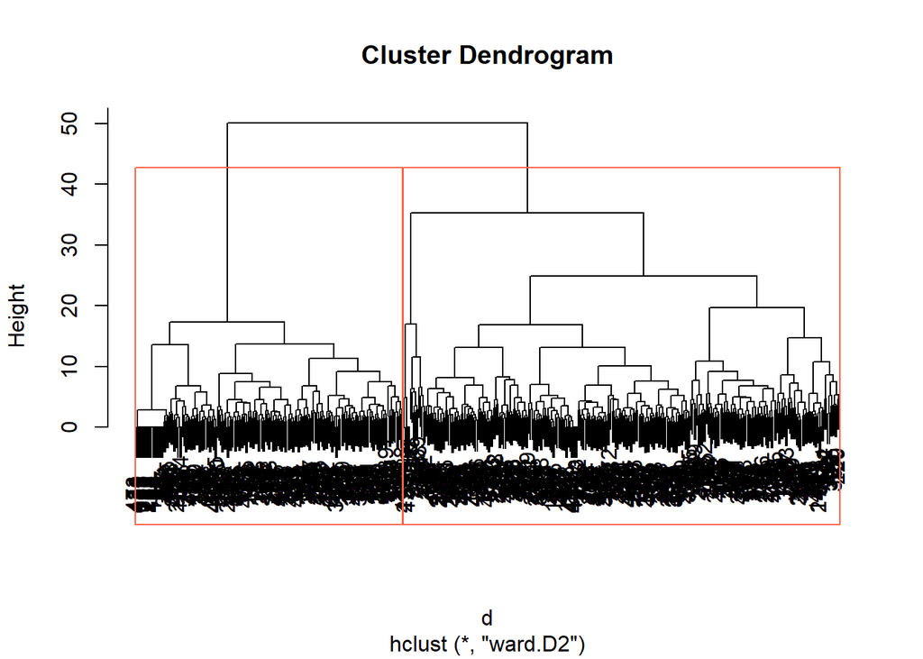

```r
plot(clusters)
rect.hclust(tree=clusters, k=2, border='tomato')
```

Now, let us do the same for a three cluster solution

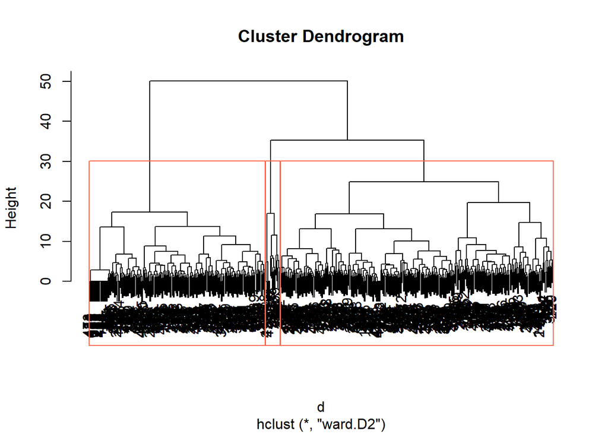

```r
plot(clusters)
rect.hclust(tree=clusters, k=3, border='tomato')
```

Now, let us do the same for a four cluster solution. The solution indicates three major segments and one niche-segment.

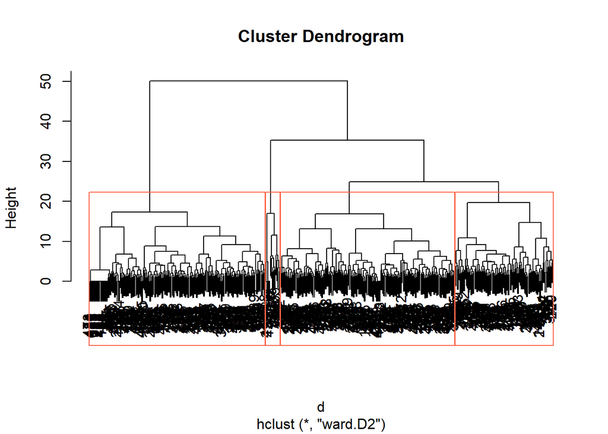

```r
plot(clusters)
rect.hclust(tree=clusters, k=4, border='tomato')
```

##### Use dendextend

Let us highlight a two cluster solution using dendextend

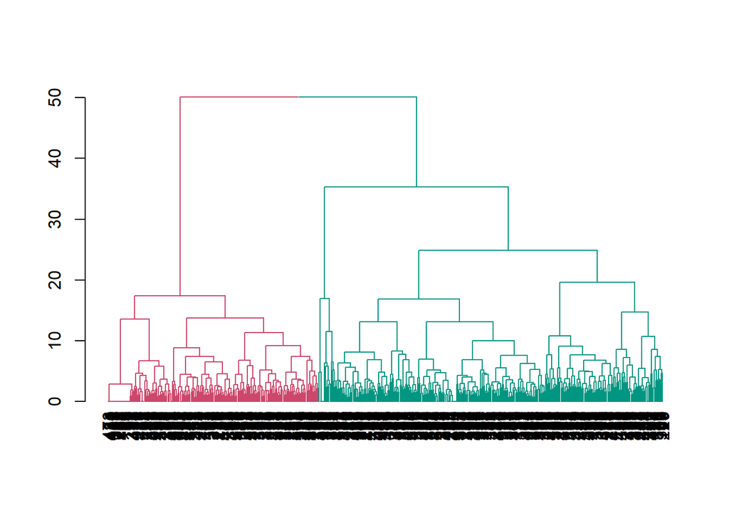

```r
library(dendextend)
plot(color_branches(as.dendrogram(clusters), k=2, groupLabels = F))
```

Let us highlight a three cluster solution using dendextend

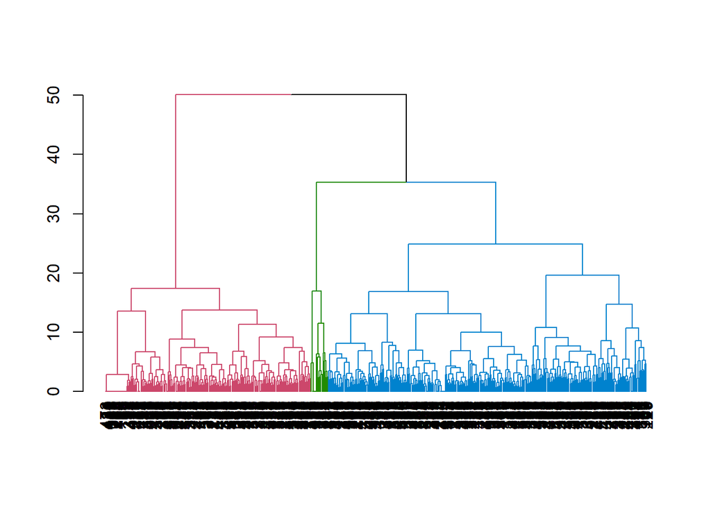

```r
library(dendextend)
plot(color_branches(as.dendrogram(clusters), k=3, groupLabels = F))
```

And, now a four cluster solution using dendextend

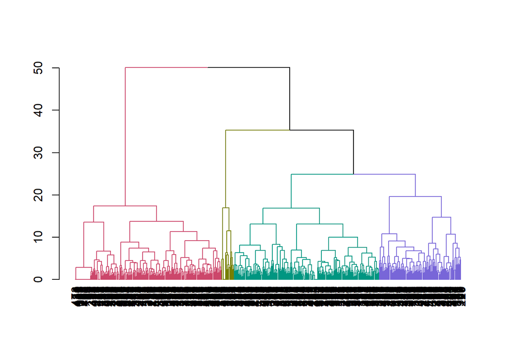

```r
library(dendextend)
plot(color_branches(as.dendrogram(clusters), k=4, groupLabels = F))
```

##### Use factoextra

Another useful library for visualizing a dendrogram is the fviz_dend from library(factoextra). Highlight two clusters.

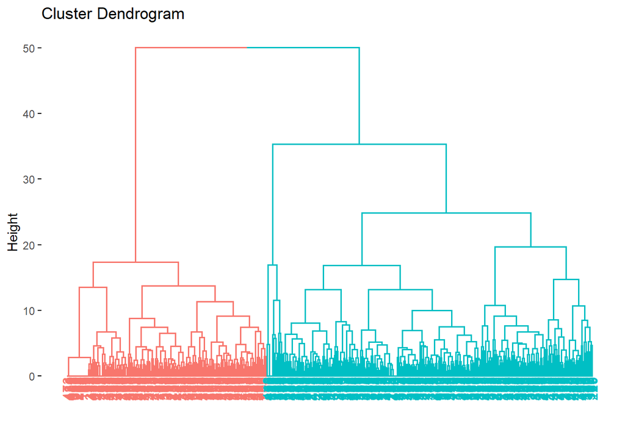

```r
library(factoextra)
fviz_dend(x = clusters,k=2)
```

Three Clusters

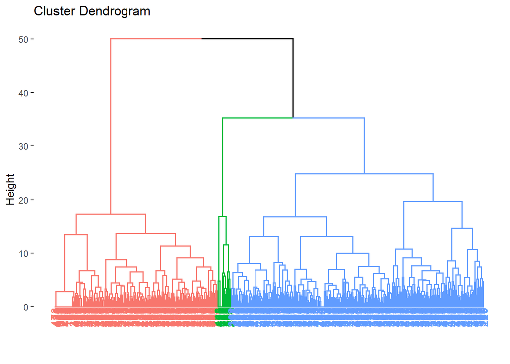

```r
library(factoextra)
fviz_dend(x=clusters,k=3)
```

Four Clusters

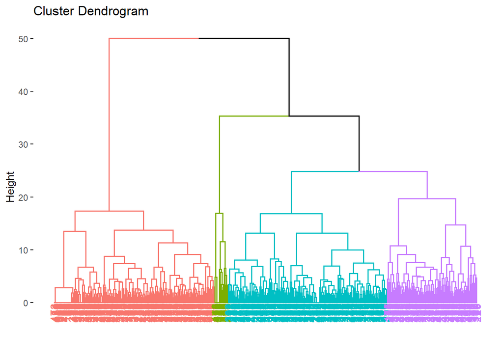

```r
library(factoextra)
fviz_dend(x=clusters,k=4)
```

From the default color palette of above charts, it may be obvious that this fviz_dend generates a ggplot2 object. This makes other packages such as gridExtra that use ggplot objects accessible.

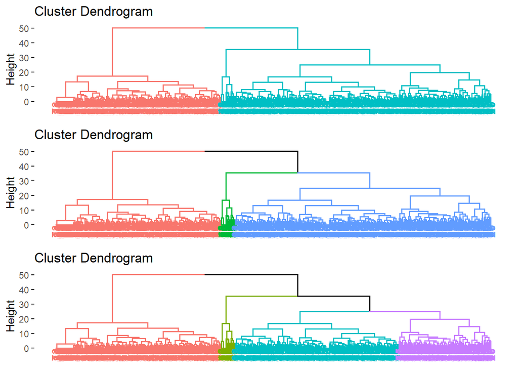

```r
library(gridExtra)
grid.arrange(fviz_dend(x=clusters, k=2),
             fviz_dend(x=clusters, k=3),
             fviz_dend(x=clusters, k=4)
)
```

### Selecting Clusters

Number of clusters may be determined by examining the height between branch splits. Combining distances and domain knowledge, a four-cluster solution seems to be best. Most of the respondents seem to be clustering into three groups with the fourth cluster containing a very small number of respondents. For a financial services company, three major segments and one niche segment is a reasonable number of segments to cater to. Based on these considerations, we cut the data into four clusters.

```r
h_segments = cutree(tree=clusters, k=4)
h_segments
```

```
##   [1] 1 2 1 3 3 3 3 1 3 1 1 2 1 1 1 1 3 1 1 3 2 3 3 1 2 2 3 3 3 1 2 1 1 3 3 3 3
##  [38] 3 2 1 1 3 2 4 2 1 2 2 3 3 3 1 1 2 3 3 2 1 1 3 3 3 1 3 3 3 3 1 2 2 2 3 1 1
##  [75] 3 2 2 2 1 1 1 3 1 2 2 2 3 3 1 1 1 2 2 2 2 3 3 3 3 1 3 2 3 1 3 1 3 3 2 3 2
## [112] 3 3 3 1 1 3 3 1 3 3 3 4 2 1 3 3 3 2 3 1 1 2 1 2 4 4 1 3 2 3 3 1 2 1 3 1 2
## [149] 3 3 2 3 1 3 1 3 3 4 3 2 1 3 2 3 3 1 2 3 1 1 1 1 1 2 2 1 1 3 3 3 1 2 2 1 2
## [186] 1 1 1 1 2 1 3 3 1 2 1 3 3 1 1 1 1 2 3 2 3 3 4 2 2 2 3 3 1 2 2 3 1 3 1 2 1
## [223] 1 3 3 1 3 1 2 3 3 1 1 3 3 3 2 4 2 1 2 1 1 1 1 4 3 2 1 3 1 2 4 3 1 3 3 1 3
## [260] 2 1 3 1 1 3 3 1 3 1 1 2 1 1 1 1 3 2 1 1 2 1 3 1 2 1 3 1 3 3 4 2 3 3 3 3 3
## [297] 1 3 2 1 1 1 2 3 3 2 2 1 1 3 1 3 2 1 1 2 3 1 3 3 1 1 1 1 3 2 1 1 1 1 1 2 3
## [334] 1 3 2 3 1 1 1 1 3 3 3 1 2 3 1 1 2 1 2 1 1 3 3 3 3 4 2 3 1 1 1 1 3 4 3 3 3
## [371] 2 1 1 3 3 3 1 1 1 2 1 3 3 4 3 1 1 1 2 3 1 2 3 3 1 1 3 3 1 1 1 3 3 2 1 1 3
## [408] 1 3 2 3 3 2 1 1 1 3 4 2 1 2 1 2 1 3 2 1 3 3 3 1 3 3 3 1 3 3 3 3 3 3 3 3 2
## [445] 3 1 2 1 1 1 2 3 2 3 3 3 2 1 4 2 1 2 3 1 3 1 2 1 1 1 3 2 3 1 4 1 1 3 3 1 2
## [482] 1 1 2 3 2 3 1 2 3 1 2 3 1 3 1 2 3 1 3
```

```r
table(h_segments)
```

```
## h_segments
##   1   2   3   4
## 188 106 190  16
```

### Visualize

To express the clusters on a scatterplot, we flatten the data from 12 dimensions onto 2 by conducting a factor analysis with varimax rotation. This is done because it is not possible to visualize 12-dimensional data.

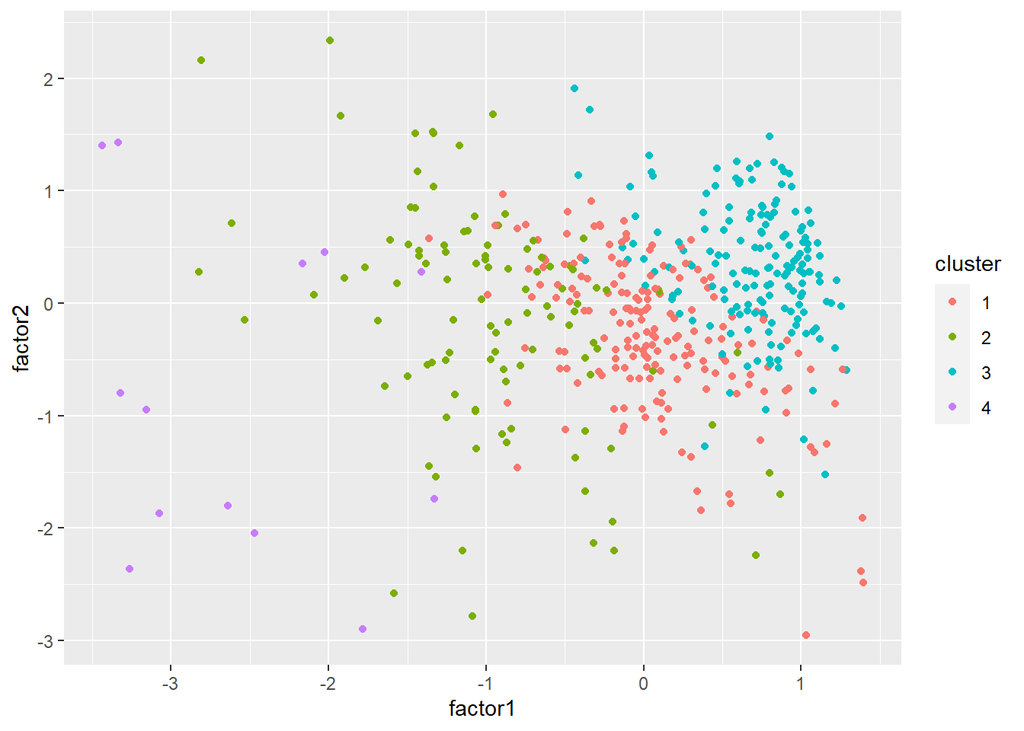

```r
library(psych)
temp = data.frame(cluster = factor(h_segments),
           factor1= fa(data_cluster,nfactors=2, rotate ='varimax')$scores[,1],
           factor2= fa(data_cluster,nfactors=2, rotate ='varimax')$scores[,2])

ggplot(temp,aes(x=factor1,y=factor2,col=cluster))+
  geom_point()
```

##### Using clusplot

`clusplot` does something similar. Rather than running a factor analysis, it runs a principal components analysis.

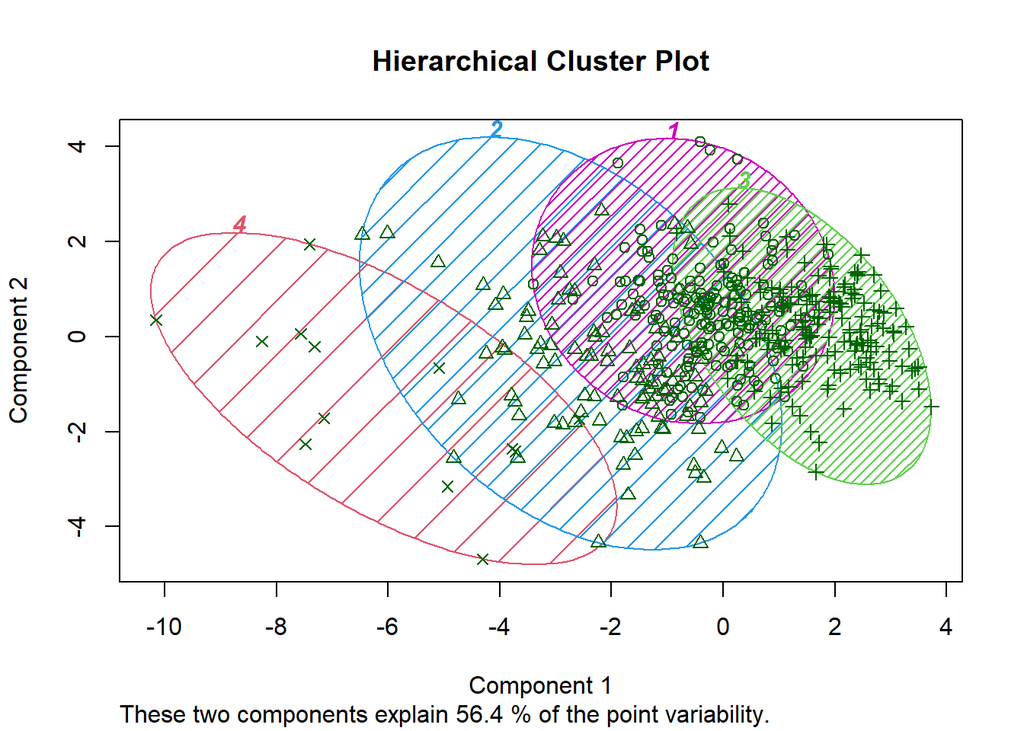

```r
library(cluster)
clusplot(data_cluster,
         h_segments,
         color=T, shade=T, labels=4, lines=0, main='Hierarchical Cluster Plot')
```

# K-means Clustering

- Attempts to find groups that are most compact, in terms of the mean sum-of-squares deviation of each observation from the multivariate center (centroid) of its assigned group
- Non-hierarchical process that reaches solution through an iteration
- K-means clustering begins by arbitrarily placing centroids in the data and then iterating from that point to the final solution. This disorganized approach to clustering produces similar quality of clusters to hierarchical clustering but much faster

## Compute Similarity Measure

For k-means, the distance is computed using Euclidean distance.

## Clustering Method

Unlike the agglomerative process of hierarchical clustering, k-means begins with an arbitrary assignment of observations to cluster centroids. (Seed is important for reproducibility). Then it uses an iterative process that involves updating cluster centers and reassigning observations. Updating is done to minimize sum of squares from observations to cluster centers. Method of updating is defined by algorithms including “Hartigan-Wong” (default), “Lloyd”, “Forgy”, “MacQueen”

Let us begin with an arbitrary choice of 3 centers. Later, we will examine objective methods for picking the number of centers.

```r
set.seed(617)
km = kmeans(x=data_cluster, centers=3, iter.max=10000, nstart=25)
```

Here are the number of observations in the resulting clusters

```r
k_segments = km$cluster
table(k_segments)
```

```
## k_segments
##   1   2   3
## 193 253  54
```

k-means examines sum of squared distances in evaluating cluster solutions. The total sum of squares is the sum of total within-cluster sum of squares and the between cluster sum of squares

```r
paste(km$totss, '=', km$betweenss, '+', km$tot.withinss, sep = ' ')
```

```
## [1] "5988 = 2098.09016012787 + 3889.90983987213"
```

```r
km$totss == km$betweenss + km$tot.withinss
```

```
## [1] TRUE
```

## Intepret Results

### Number of Clusters

Aside from domain knowledge driven a priori choices of number of clusters, there are also a few data-driven approaches to determine cluster solutions. These methods rely on measures of distance of points from the clusters they are assigned to. The three methods we will look at include

- Total within sum of squares plot
- Ratio plot
- Silhouette plot

##### Total within sum of squares Plot

Compute total within sum of squares for a number of values of k. Plot a line graph of k (on x-axis) against total within sum of squares (on y-axis). Ideal number of clusters is inferred from a sudden change in the line graph or what is commonly known as the “elbow”.

To construct the plot, we will get the total within sum of squares for a set of 10 cluster solutions.

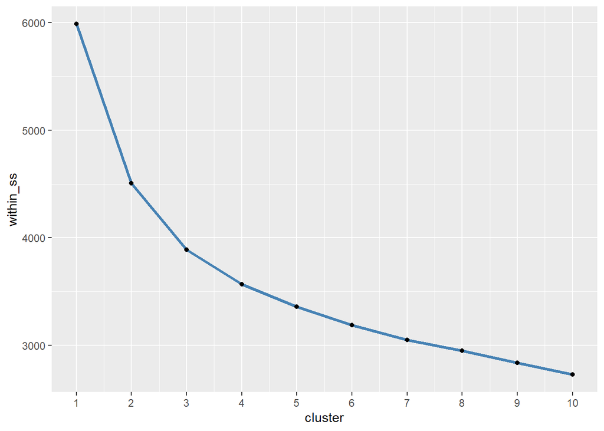

```r
within_ss = sapply(1:10,FUN = function(x){
  set.seed(617)
  kmeans(x=data_cluster, centers=x, iter.max=1000, nstart=25)$tot.withinss})

ggplot(data=data.frame(cluster = 1:10,within_ss), aes(x=cluster,y=within_ss))+
  geom_line(col='steelblue',size=1.2)+
  geom_point()+
  scale_x_continuous(breaks=seq(1,10,1))
```

The total within cluster sum of squares for a two-cluster and three cluster solution?

```r
within_ss[2]
```

```
## [1] 4504.764
```

```r
within_ss[3]
```

```
## [1] 3889.91
```

##### Ratio Plot

Another alternative that generates a similar conclusion is to compute the ratio of between cluster sum of squares and total sum of squares for a number of values of k. Ideal number of clusters is inferred from the elbow in the graph.

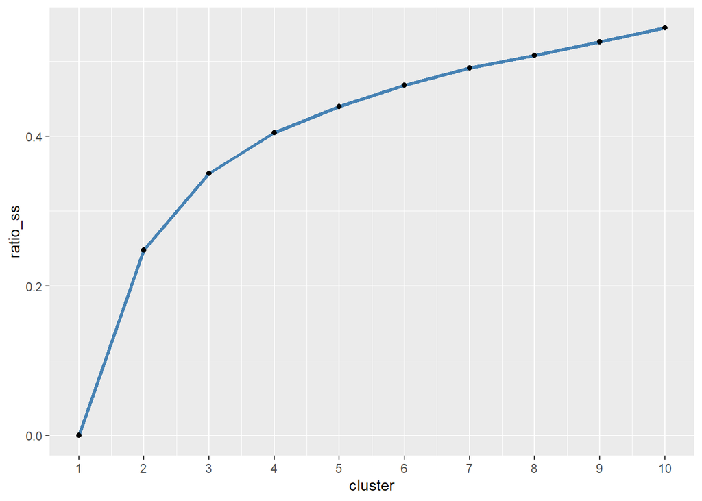

```r
ratio_ss = sapply(1:10,FUN = function(x) {
  set.seed(617)
  km = kmeans(x=data_cluster, centers=x, iter.max=1000, nstart=25)
  km$betweenss/km$totss} )

ggplot(data=data.frame(cluster = 1:10,ratio_ss), aes(x=cluster,y=ratio_ss))+
  geom_line(col='steelblue',size=1.2)+
  geom_point()+
  scale_x_continuous(breaks=seq(1,10,1))
```

##### Silhouette Plot

Silhouette analysis reflects how well points fit in their respective clusters. It involves computing the silhouette width(s(i)) for each point  
s(i) = (b(i) - a(i))/max{a(i),b(i)}  
where

- a(i) is average distance of a point to all observations within its cluster
- b(i) is the average distance of a point to all observations in the nearest cluster

-1 <= s(i) <= 1

- s(i) = 1 implies i is in the right cluster
- s(i) = 0 implies i is between two clusters
- s(i) = -1 implies i should be in the nearest cluster

Silhoette width is easily computed using pam() from library(cluster). Partitioning around medoids (pam) is a more robust verion of k-means that clusters data using medoids rather than centroids. This means, the Silhouette width we compute using pam() is not exactly the same as that from kmeans() but the numbers are pretty close. Since we don’t have a handy function to compute silhouette width for k-means, we will use the one computed on pam() and use it instead. (You can examine the result of pam() if you are curious about this function and its attributes).

```r
library(cluster)
pam(data_cluster, k=3)$silinfo$avg.width
```

```
## [1] 0.09462411
```

We can easily modify the above code to find Silhouette width for a four-cluster solution

```r
library(cluster)
pam(data_cluster, k=4)$silinfo$avg.width
```

```
## [1] 0.07399345
```

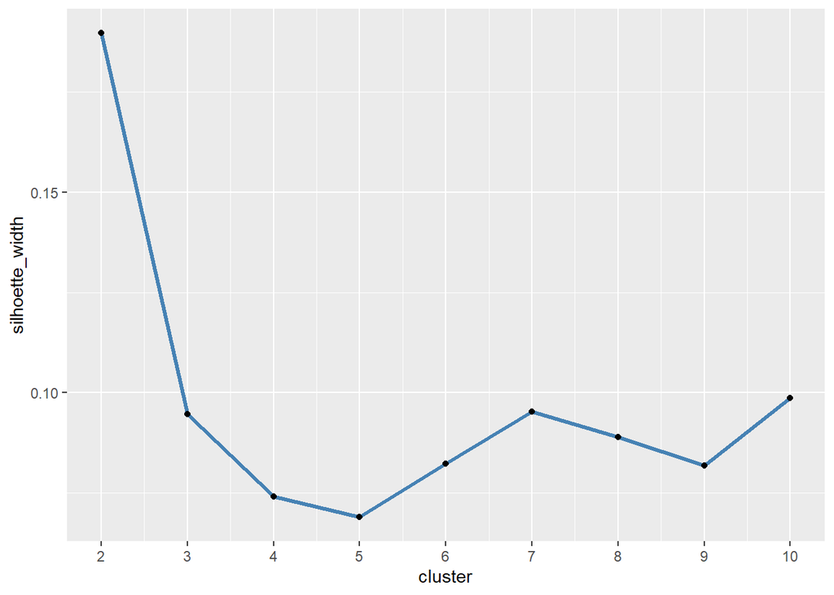

```r
library(cluster)
silhoette_width = sapply(2:10,
                         FUN = function(x) pam(x=data_cluster, k=x)$silinfo$avg.width)

ggplot(data=data.frame(cluster = 2:10,silhoette_width), aes(x=cluster,y=silhoette_width))+
  geom_line(col='steelblue',size=1.2)+
  geom_point()+
  scale_x_continuous(breaks=seq(2,10,1))
```

The total within sum of square and ratio plots support a two-, three- and four- cluster solution while silhoette supports a two-cluster solution. Of these alternatives, the two- and three- cluster solutions combine a niche segment into a larger segment. (See number of observations in smallest segment from a 4-cluster solution). In order to tease out this niche segment, and focus on three dominant segments, we will go with a four-cluster solution.

```r
set.seed(617)
km = kmeans(x=data_cluster, centers=4, iter.max=10000, nstart=25)
```

Size of the clusters

```r
k_segments = km$cluster
table(k_segments)
```

```
## k_segments
##   1   2   3   4
## 221 110 155  14
```

### Visualize

To express the clusters on a scatterplot, we flatten the data from 12 dimensions onto 2 by conducting a factor analysis with varimax rotation. This is done because it is not possible to visualize 12-dimensional data.

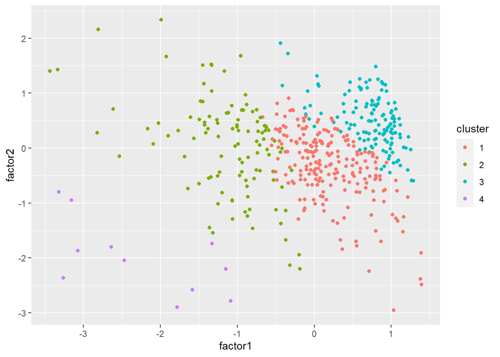

```r
library(psych)
temp = data.frame(cluster = factor(k_segments),
           factor1= fa(data_cluster, nfactors=2, rotate='varimax')$scores[,1],
           factor2= fa(data_cluster, nfactors=2, rotate='varimax')$scores[,2])

ggplot(temp, aes(x=factor1,y=factor2,col=cluster))+
  geom_point()
```

##### Using clusplot

`clusplot` does something similar.

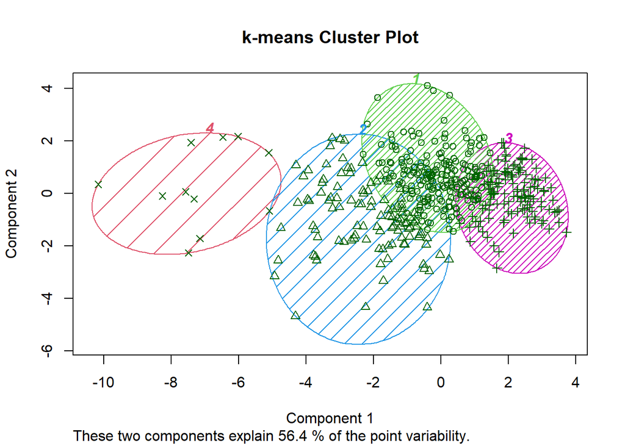

```r
library(cluster)
clusplot(data_cluster,
         k_segments,
         color=T, shade=T, labels=4, lines=0, main='k-means Cluster Plot')
```

# Model-based clustering

Key idea of model-based clustering is that observations come from groups with different statistical distributions (such as different means and variances). The algorithms try to find the best set of such underlying distributions to explain the observed data. These methods are also known as mixture models because it is assumed that the data reflect a mixture of observations drawn from different populations.

## Clustering Method

mclust() models such clusters as being drawn from a mixture of normal (also known as Gaussian) distributions.

```r
library(mclust)
clusters_mclust = Mclust(data_cluster)
```

The optimal cluster solution is the one that performs best on BIC and log.likelihood

```r
summary(clusters_mclust)
```

```
## ----------------------------------------------------
## Gaussian finite mixture model fitted by EM algorithm
## ----------------------------------------------------
##
## Mclust EEV (ellipsoidal, equal volume and shape) model with 6 components:
##
##  log-likelihood   n  df       BIC       ICL
##       -3903.212 500 485 -10820.51 -10840.66
##
## Clustering table:
##   1   2   3   4   5   6
##  12 198  15 166  92  17
```

Of course, one can impose a cluster solution and examine how much worse the log.likelihood and BIC get. Now, a word of caution, some R functions including mclust generate negative of BIC (Chapman and Feit 2015) which makes interpretation a bit confusing. To interpret BIC, reverse the sign of the bic reported. Now, lower the bic, better the cluster solution. This means, a solution of -(-11309.5) is better than -(-14546.64).

```r
clusters_mclust_3 = Mclust(data_cluster, G=3)
summary(clusters_mclust_3)
```

```
## ----------------------------------------------------
## Gaussian finite mixture model fitted by EM algorithm
## ----------------------------------------------------
##
## Mclust EEV (ellipsoidal, equal volume and shape) model with 3 components:
##
##  log-likelihood   n  df       BIC       ICL
##       -6170.399 500 248 -13882.02 -13882.57
##
## Clustering table:
##   1   2   3
## 200  43 257
```

```r
clusters_mclust_3$bic
```

```
## [1] -13882.02
```

## Intepret Results

### Plot of bic (Bayesian Information Criterion)

Let us generate the Bayesian Information Criterion (bic) for a series of cluster solutions and plot them. Note, the sign of the default bic has been reversed, so we will be looking for the lowest bic in the line graph.

```r
mclust_bic = sapply(1:10, FUN = function(x) -Mclust(data_cluster, G=x)$bic)
mclust_bic
```

```
##    EEE,1
## 14895.79 14900.60 13882.02 14182.20 14077.96 10820.51 11614.45 14048.39
##
## 13872.31 13138.63
```

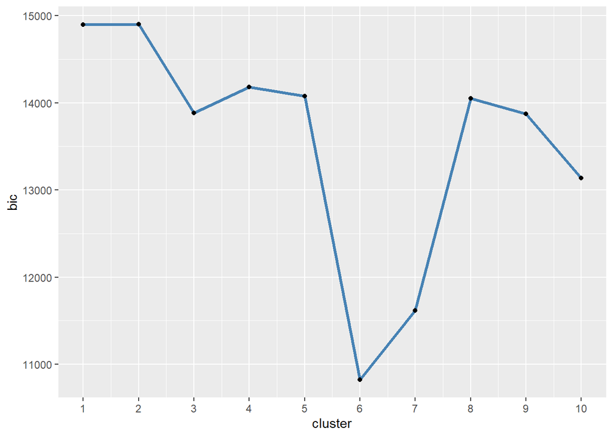

```r
ggplot(data=data.frame(cluster = 1:10, bic = mclust_bic), aes(x=cluster,y=bic))+
  geom_line(col='steelblue',size=1.2)+
  geom_point()+
  scale_x_continuous(breaks=seq(1,10,1))
```

The six-cluster solution has the lowest bic but catering to so many segments may not be practical. Moreover, both hierarchical and k-means favored a four-cluster solution, so we are going to go with a four-cluster solution.

```r
m_clusters = Mclust(data=data_cluster, G = 4)
```

Size of the clusters

```r
m_segments = m_clusters$classification
table(m_segments)
```

```
## m_segments
##   1   2   3   4
## 231 200  43  26
```

### Visualize

To express the clusters on a scatterplot, we flatten the data from 12 dimensions onto 2 by conducting a factor analysis with varimax rotation. This is done because it is not possible to visualize 12-dimensional data.

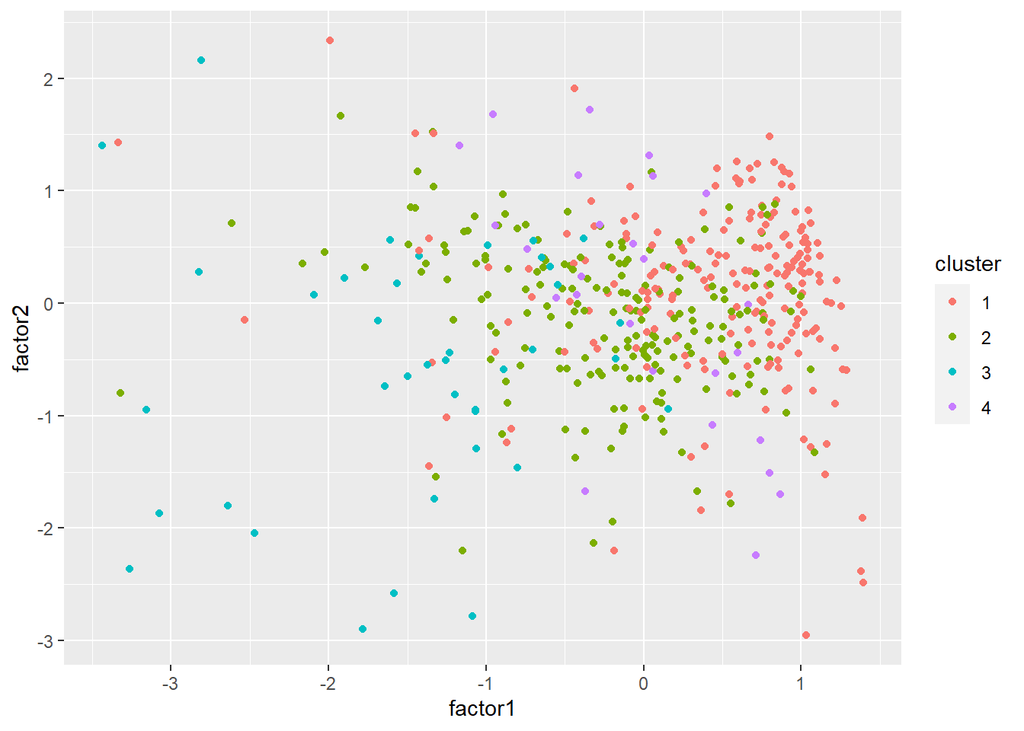

```r
library(psych)
temp = data.frame(cluster = factor(m_segments),
           factor1= fa(data_cluster, nfactors=2, rotate='varimax')$scores[,1],
           factor2= fa(data_cluster, nfactors=2, rotate='varimax')$scores[,2])

ggplot(temp,aes(x=factor1, y=factor2, col=cluster))+
  geom_point()
```

##### Using clusplot

`clusplot` does something similar.

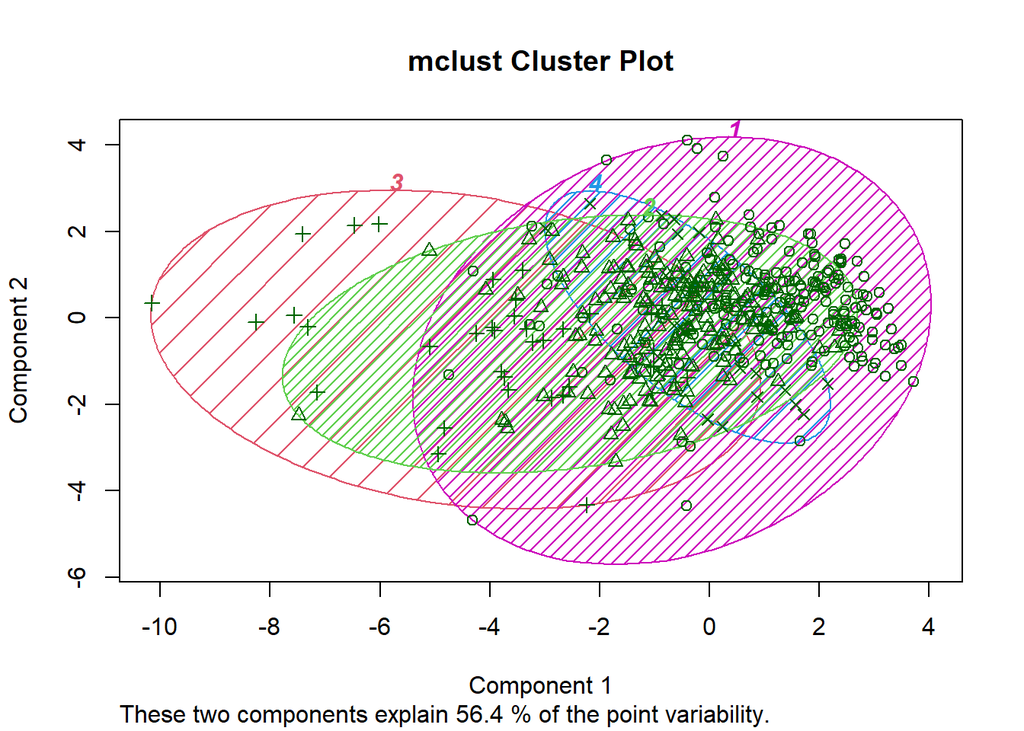

```r
library(cluster)
clusplot(data_cluster,
         m_segments,
         color=T, shade=T, labels=4, lines=0, main='mclust Cluster Plot')
```

# Contrast Results

The pattern of cluster assignments for hiearchical and k-means are quite similar (although the actual cluster numbers are not the same). The different results of model-based clustering may have to do with the way mixture models work.

```r
table(h_segments)
```

```
## h_segments
##   1   2   3   4
## 188 106 190  16
```

```r
table(k_segments)
```

```
## k_segments
##   1   2   3   4
## 221 110 155  14
```

```r
table(m_segments)
```

```
## m_segments
##   1   2   3   4
## 231 200  43  26
```

# Profile Clusters

Let us use the k-means clusters to inspect the characteristics of each cluster based on (1) needs-based variables, and (2) demographics. Profiling clusters by needs-based variables will help us understand how the four market segments differ in their needs which in turn will aid the firm in offering products and services to match the unique needs of the segment. Profiling clusters on demographics or observable variables will help identify customers and target them with the right offer.

Combine segment membership with original data

```r
data2 = cbind(data, h_segments, k_segments, m_segments)
```

## Profile Segments by Needs

Use k-means segments to examine means of each needs-based variable. Of course, in examining profiles of these segments, bear in mind that segment 4 with only 14 observations (14/500 = 2.8%) is at best a niche segment.

```r
library(dplyr)
data2 %>%
  select(performance:quality_of_service, k_segments)%>%
  group_by(k_segments)%>%
  summarize_all(function(x) round(mean(x,na.rm=T),2))%>%
  data.frame()
```

| k_segments | performance | fees_commissions | depth_of_products | ability_resolve_problems | online_services | choice_of_providers | quality_of_advice | knowledge_of_reps | rep_knowing_your_needs | professional_services | provider_knows_me | quality_of_service |
| --- | --- | --- | --- | --- | --- | --- | --- | --- | --- | --- | --- | --- |
| 1 | 4.37 | 3.58 | 3.60 | 3.80 | 2.16 | 3.17 | 4.37 | 4.34 | 4.12 | 3.38 | 3.76 | 4.39 |
| 2 | 3.86 | 3.83 | 3.46 | 3.55 | 2.73 | 3.08 | 3.35 | 3.34 | 2.75 | 2.66 | 2.49 | 4.09 |
| 3 | 4.74 | 4.15 | 4.54 | 4.71 | 3.39 | 4.14 | 4.93 | 4.93 | 4.84 | 4.24 | 4.54 | 4.92 |
| 4 | 1.62 | 2.54 | 1.15 | 1.43 | 1.62 | 1.00 | 1.85 | 1.29 | 2.17 | 1.15 | 1.38 | 3.21 |

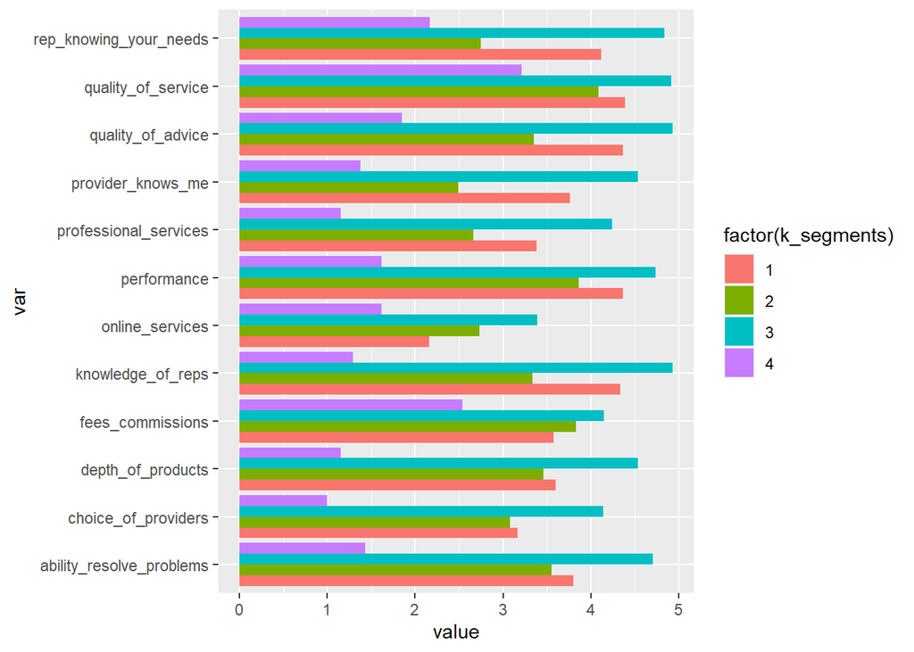

```r
library(dplyr); library(ggplot2); library(tidyr)
data2 %>%
  select(performance:quality_of_service, k_segments)%>%
  group_by(k_segments)%>%
  summarize_all(function(x) round(mean(x,na.rm=T),2))%>%
  gather(key = var,value = value,performance:quality_of_service)%>%
  ggplot(aes(x=var,y=value,fill=factor(k_segments)))+
    geom_col(position='dodge')+
    coord_flip()
```

##### Can you describe what each segment values? How do these segments differ in the things they value?

## Profile Segments by Demographics

Since data on age, marital status and education are ordinal, it is best to examine counts or proportions. Using prop.table, we can find the proportion of each age group for each segment.

```r
prop.table(table(data2$k_segments,data2[,14]), 1)
```

```
##
##          27-57      58-68      69-75        75+
##   1 0.08962264 0.24056604 0.36792453 0.30188679
##   2 0.14285714 0.26666667 0.30476190 0.28571429
##   3 0.14666667 0.30000000 0.33333333 0.22000000
##   4 0.00000000 0.21428571 0.35714286 0.42857143
```

A heatmap may be easier to interpret.

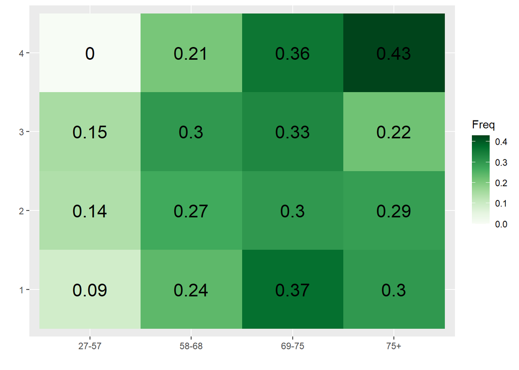

```r
library(ggplot2)
library(RColorBrewer)

tab = prop.table(table(data2$k_segments,data2[,14]), 1)
tab2 = data.frame(round(tab, 2))

ggplot(data=tab2,aes(x=Var2,y=Var1,fill=Freq))+
  geom_tile()+
  geom_text(aes(label=Freq),size=6)+
  xlab(label = '')+
  ylab(label = '')+
  scale_fill_gradientn(colors=brewer.pal(n=9,name = 'Greens'))
```

Lets clean up the table for the age groups by rounding and expressing as percentages. And, using lapply, we can apply this function to all three demographic variables at one go, so we can now examine age, marital status and education.

```r
lapply(14:16,function(x) round(prop.table(table(data2$k_segments,data2[,x]), 1), 2)*100)
```

```
## [[1]]
##
##     27-57 58-68 69-75 75+
##   1     9    24    37  30
##   2    14    27    30  29
##   3    15    30    33  22
##   4     0    21    36  43
##
## [[2]]
##
##     married not married
##   1      84          16
##   2      92           8
##   3      86          14
##   4      93           7
##
## [[3]]
##
##     no college some college college graduate some graduate school
##   1          8           15               25                   12
##   2          8           20               30                    8
##   3          9           23               31                   11
##   4         14            0               36                    0
##
##     masters degree doctorate
##   1             20        19
##   2             20        14
##   3             17         9
##   4             29        21
```

Heat Maps of above crostabulations.

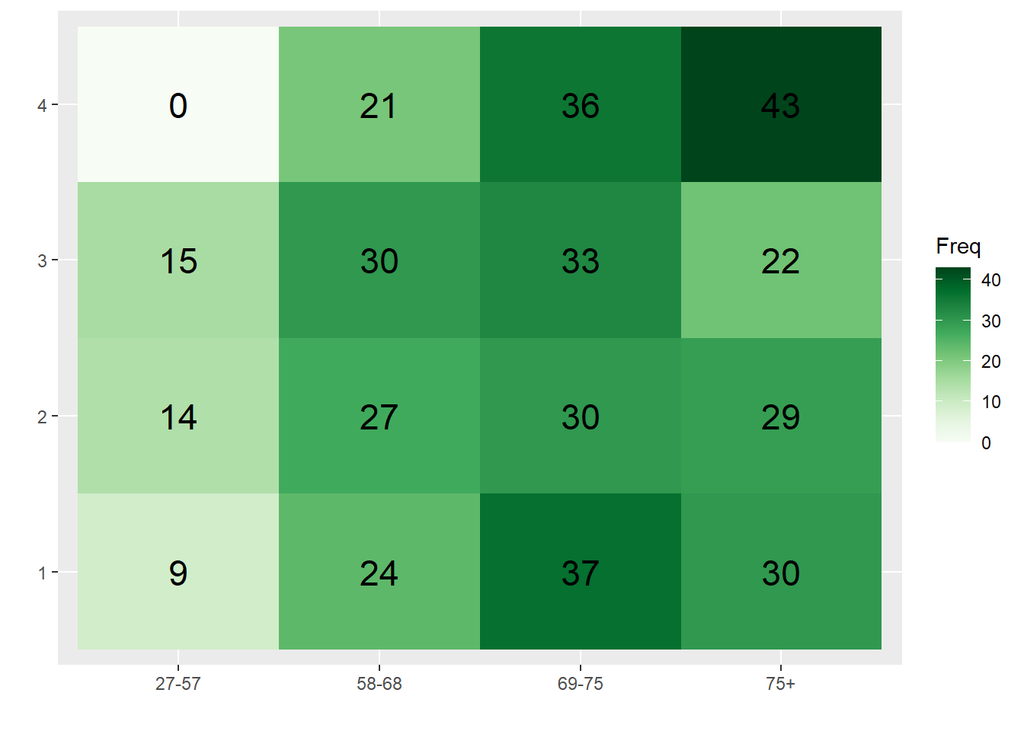

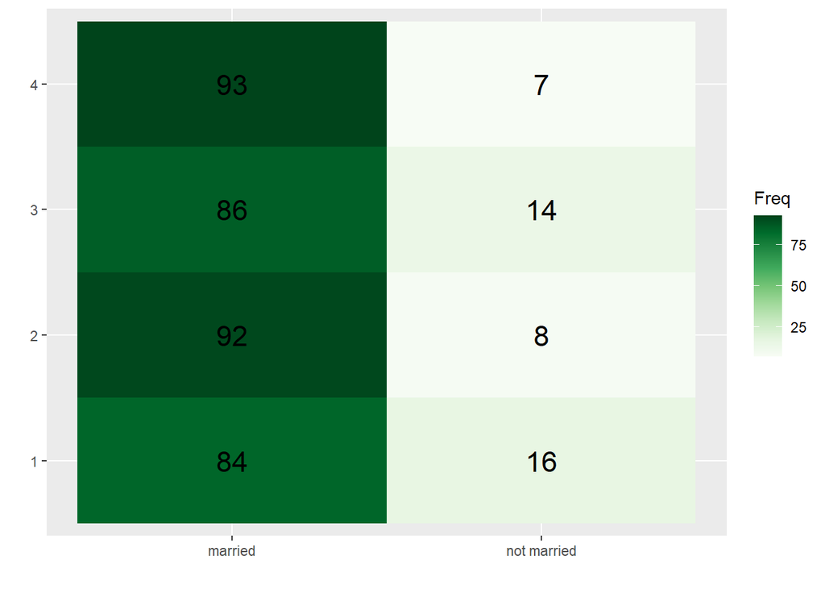

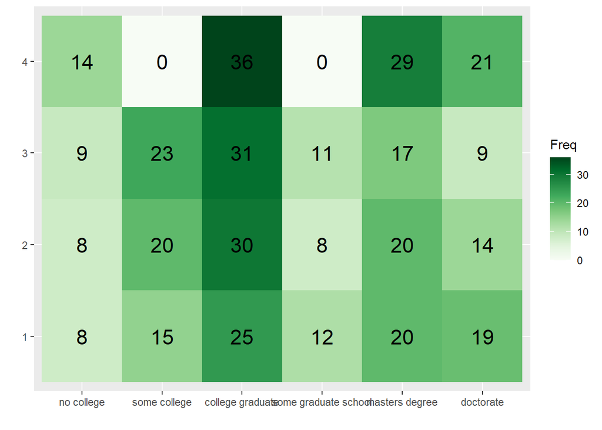

```r
lapply(14:16,function(x) {
  dat = round(prop.table(table(data2$k_segments,data2[,x]), 1), 2)*100
  dat = data.frame(dat)
  ggplot(data=dat,aes(x=Var2,y=Var1,fill=Freq))+
    geom_tile()+
    geom_text(aes(label=Freq),size=6)+
    xlab(label = '')+
    ylab(label = '')+
    scale_fill_gradientn(colors=brewer.pal(n=9,name = 'Greens'))
})
```

##### Can you describe the customers in each segment? How do these segments differ?

This file was generated using R Version 4.1.2